# Evaluate correlation between Chester and Penn’s Landing

J Hagy

2024-07-08

During external review of the Technical Report, one reviewer noted that some of the gaps in the data are longer than 1 or 2 days and suggested that EPA consider using data from the other site to impute missing values, rather than just interpolating linearly. Commenters allso suggested that EPA consider this approach. This program evaluates if this approach is feasible and if it could provide an improved approach to impute missing data from the daily time series.

## Load data

```r
load(here("data","5. Chester_1961-2023.Rdata"))
load(here("data","5.01 Delaware River at Penn Landing.Rdata"))
```

## How often are both stations missing at the same time?

```r
dates.template <- data.frame(date=seq(as.Date("2002-01-01"),
                      as.Date("2022-12-31"),by=1))

df.C <- drChester_ctdo %>%
  select(date,do.mgL.mean) %>%
  left_join(dates.template,.,by="date") %>%
  rename(chester = do.mgL.mean)

df.P <- drPenn_ctdo %>%
  select(date,do.mgL.mean) %>%
  left_join(dates.template,.,by="date") %>%
  rename(Penn = do.mgL.mean)

df <- cbind(df.C,select(df.P,Penn)) %>%
  filter(between(yday(date),182,305))

df$bothMissing <- is.na(df$chester) & is.na(df$Penn)

df$onlyChester <- is.na(df$chester) & !is.na(df$Penn)
df$onlyPenn <- is.na(df$Penn) & !is.na(df$chester)
summary(df$bothMissing)
```

```
##    Mode   FALSE    TRUE
## logical    2584      20
```

In the data, there were only 20 days when data from both sites were missing. Of these, 6 days were in 2005, 1 was in 2007, and 13 were in 2010. Data from 2010 were not included in the analysis because too much data was missing.

```r
summary(df$onlyChester)
```

```
##    Mode   FALSE    TRUE
## logical    2487     117
```

```r
df %>% filter(onlyChester) %>%
  mutate(year=year(date)) %>%
  group_by(year) %>%
  summarize(n=n())
```

```
## # A tibble: 13 × 2
##     year     n
##    <dbl> <int>
##  1  2002     3
##  2  2004    19
##  3  2005    16
##  4  2006     9
##  5  2007    22
##  6  2009     3
##  7  2010     7
##  8  2011     1
##  9  2012     2
## 10  2013     9
## 11  2018     1
## 12  2019     8
## 13  2020    17
```

Missing data at Chester was concentrated early in the record, such as 2004, 2005, 2007, and again in 2020.

```r
summary(df$onlyPenn)
```

```
##    Mode   FALSE    TRUE
## logical    2496     108
```

```r
df %>% filter(onlyPenn) %>%
  mutate(year=year(date)) %>%
  group_by(year) %>%
  summarize(n=n())
```

```
## # A tibble: 10 × 2
##     year     n
##    <dbl> <int>
##  1  2003     5
##  2  2004    11
##  3  2005     5
##  4  2006     6
##  5  2007    21
##  6  2008     4
##  7  2010    24
##  8  2016     1
##  9  2021    12
## 10  2022    19
```

Data missing only at Penn’s Landing was concentrated more later in the record, except for 2010, where the most missing values occurred. Note that because of missing data, 2010 was not included in the analysis used to develop the rule. Therefore, imputation of missing data in 2010 was not needed.

# Relationship between DO at Penn’s Landing and Chester

As suggested by the reviewer, if there is a strong relationship between observations and the data at the two sites, it might be possible to make a more accurate imputation using non-missing data from the other site.

Here we look at predicting data for Chester using non-missing data from Penn’s Landing.

```r
# fit a linear model to predict values at Chester from values at Penn's Landing
fit <- lm(chester ~ Penn,data=df)
summary(fit)
```

```
##
## Call:
## lm(formula = chester ~ Penn, data = df)
##
## Residuals:
##      Min       1Q   Median       3Q      Max
## -2.58711 -0.40803  0.00348  0.37220  2.92920
##
## Coefficients:
##             Estimate Std. Error t value Pr(>|t|)
## (Intercept)  2.51764    0.05921   42.52   <2e-16 ***
## Penn         0.60460    0.00981   61.63   <2e-16 ***
## ---
## Signif. codes:  0 '***' 0.001 '**' 0.01 '*' 0.05 '.' 0.1 ' ' 1
##
## Residual standard error: 0.6463 on 2357 degrees of freedom
##   (245 observations deleted due to missingness)
## Multiple R-squared:  0.6171, Adjusted R-squared:  0.6169
## F-statistic:  3798 on 1 and 2357 DF,  p-value: < 2.2e-16
```

```r
fit$coefficients
```

```
## (Intercept)        Penn
##   2.5176378   0.6046054
```

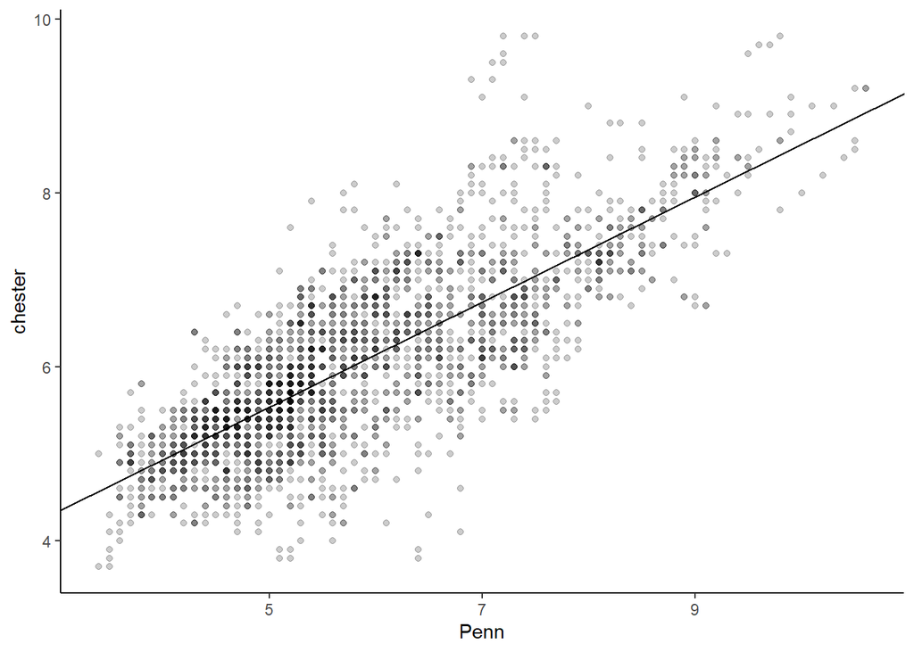

```r
# compute predicted values from MA regression
df$chester.mod <- predict(fit,df)
df <- df %>% mutate(chester.res = chester - chester.mod)

ggplot()+
  geom_point(data=df,aes(x=Penn,y=chester),alpha=0.2)+
  geom_abline(slope=fit$coefficients[2],intercept=fit$coefficients[1])+
  theme_classic()
```

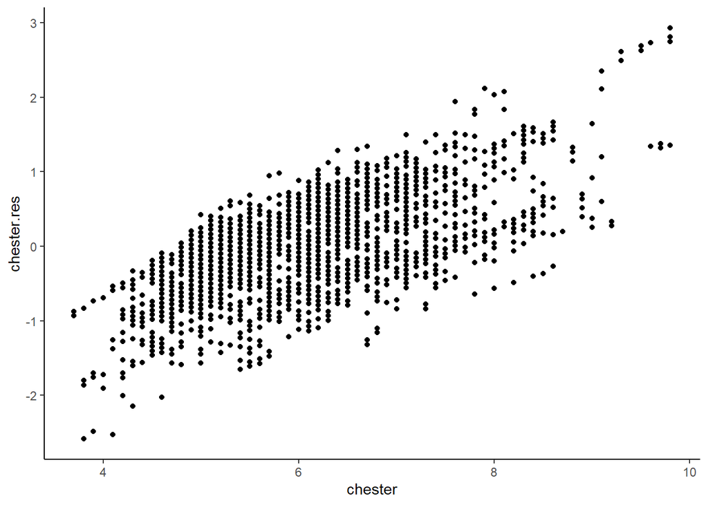

```r
ggplot(df,aes(x=chester,y=chester.res))+
  geom_point()+
  theme_classic()
```

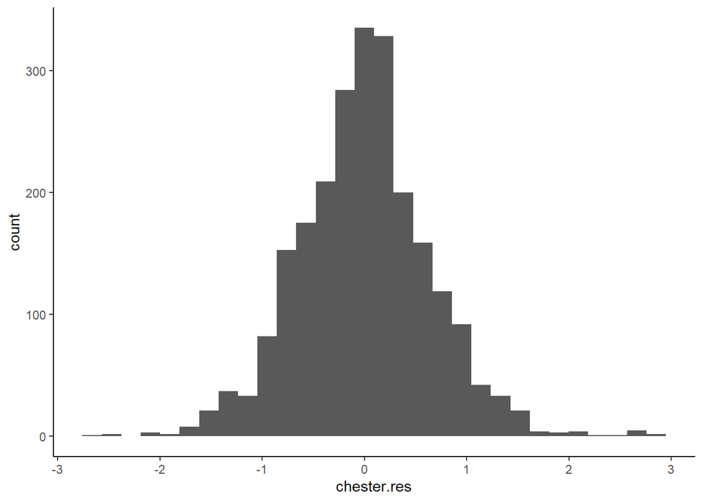

```r
ggplot(df,aes(x=chester.res))+
  geom_histogram()+
  theme_classic()
```

# What is the correlation between observations and the 1-day or 2-day lagged observation

```r
df$chester.lag1 <- lag(df$chester,1)
df$chester.lag2 <- lag(df$chester,2)
df$chester.lag3 <- lag(df$chester,3)
df$chester.lag4 <- lag(df$chester,4)
df$chester.lag5 <- lag(df$chester,5)
df$chester.lag6 <- lag(df$chester,6)

df$chester.lead1 <- lead(df$chester,1)
df$chester.lead2 <- lead(df$chester,2)
df$chester.lead3 <- lead(df$chester,3)
df$chester.lead4 <- lead(df$chester,4)
df$chester.lead5 <- lead(df$chester,5)
df$chester.lead6 <- lead(df$chester,6)

correlations <- c(
cor(df$chester,df$chester.lag1,use="complete.obs"),
cor(df$chester,df$chester.lag2,use="complete.obs"),
cor(df$chester,df$chester.lag3,use="complete.obs"),
cor(df$chester,df$chester.lag4,use="complete.obs"),
cor(df$chester,df$chester.lag5,use="complete.obs"),
cor(df$chester,df$chester.lag6,use="complete.obs")
)
correlations^2
```

```
## [1] 0.9283245 0.8316012 0.7393357 0.6623747 0.5988977 0.5442100
```

The correlation between lagged data is better than the regression correlation for the first 4 days. Correlations with leading data are identical. Therefore, it might be better to use predictions based on regression with Penn’s Landing when the gap is longer than 2x4 days = 8 days.

# How many days are in the typical “gap” at each site

```r
missingLength <- 0
gaps <- NULL
for (i in 1:2604) {
  # if chester is missing
  if (is.na(df$chester[i])) {
    missingLength <- missingLength + 1
  }
  if (!is.na(df$chester[i]) & missingLength>0) {
    gaps <- rbind(gaps,missingLength)
    missingLength <- 0
  }
}

data.frame(gaps=gaps) %>% group_by(gaps) %>%
  summarize(n=n())
```

```
## # A tibble: 10 × 2
##     gaps     n
##    <dbl> <int>
##  1     1     6
##  2     2    10
##  3     3     4
##  4     4     4
##  5     5     3
##  6     6     1
##  7     7     1
##  8     9     1
##  9    11     3
## 10    13     1
```

# Calculate missing values using both linear interpolation and regression.

```r
calcDaysMissing <- function(myYear) {
  df.filt <- filter(df,year(date)==myYear)
  # Calculate days since missing
  if (is.na(df.filt$chester[1])) {
    df$daysMissing[1] <- 1
  } else { df.filt$daysMissing[1] <- 0 }

  for (i in 2:nrow(df.filt)) {
    if (is.na(df.filt$chester[i])) {
      df.filt$daysMissing[i] <- df.filt$daysMissing[i-1]+1
    } else {
      df.filt$daysMissing[i] <- 0
    }
  }
  return(df.filt$daysMissing)
}

# Calculate number of days since data was missing
for (yr in seq(2002,2022)) {
  df$daysMissing[year(df$date)==yr] <- calcDaysMissing(yr)
}

df %>% group_by(daysMissing) %>%
  summarize(n=n())
```

```
## # A tibble: 13 × 2
##    daysMissing     n
##          <dbl> <int>
##  1           0  2467
##  2           1    33
##  3           2    27
##  4           3    17
##  5           4    13
##  6           5     9
##  7           6     6
##  8           7     5
##  9           8     4
## 10           9     4
## 11          10     3
## 12          11     3
## 13          NA    13
```